# Partie 1 : Analyse Exploratoire des Données

- Montrer tout le code
- Cacher tout le code
- Voir les sources

Compléments de Mathématiques 2 – Introduction au Machine Learning

Auteur·rice·s

HAMLIL Mohamed

PARDO TERAN German

EL KORAICHI Mohamed Yassine

ANZID Keltoum

Date de publication

2 mars 2026

# Introduction

## Contexte

Ce projet s’inscrit dans le cadre du cours de Compléments de Mathématiques 2 (Introduction au Machine Learning). L’objectif est de réaliser une classification supervisée binaire à partir d’un jeu de données réel.

Nous avons choisi un jeu de données de parfums issu de **Parfumo**, une communauté en ligne dédiée aux parfums. Ce dataset contient des informations sur près de 60 000 parfums : leur marque, année de sortie, concentration, notes olfactives, accords principaux et évaluations des utilisateurs.

**Lien de téléchargement :** [Parfumo Fragrance Dataset – TidyTuesday](https://github.com/rfordatascience/tidytuesday/blob/main/data/2024/2024-12-10/readme.md)

**NoteObjectif**

Prédire la **satisfaction des utilisateurs** (variable binaire : Oui / Non) à partir des caractéristiques d’un parfum. La satisfaction est définie par la note attribuée par les utilisateurs (`Rating_Value`) : un parfum est considéré comme satisfaisant si sa note est supérieure ou égale à la médiane.

## Variables utilisées

| Variable | Type | Description |
| --- | --- | --- |
| `Release_Year` | Numérique | Année de sortie du parfum |
| `Concentration` | Catégorielle | Type de concentration (EDP, EDT, etc.) |
| `Rating_Count` | Numérique | Nombre d’évaluations reçues |
| `Main_Accords` | Texte | Accords olfactifs principaux |
| `Top_Notes` | Texte | Notes de tête |
| `Middle_Notes` | Texte | Notes de cœur |
| `Base_Notes` | Texte | Notes de fond |
| **`Satisfaction`** | **Binaire** | **Variable cible (Oui / Non)** |

# Chargement des données

```r
data_raw <- read.csv(here::here("data", "parfumo_data_clean.csv"),
                     stringsAsFactors = FALSE,
                     na.strings = c("NA", ""))

cat("Dimensions du dataset brut :", nrow(data_raw), "lignes,", ncol(data_raw), "colonnes\n")
```

```
Dimensions du dataset brut : 59325 lignes, 13 colonnes
```

# Analyse préliminaire des données

## Aperçu général

```r
str(data_raw)
```

```
'data.frame':   59325 obs. of  13 variables:
 $ Number       : chr  "455" "0071" "0154" "0162" ...
 $ Name         : chr  "Tabac Écarlate" "Tidal Pool" "Pumpkin Pie" "Wet Stone" ...
 $ Brand        : chr  "Le Ré Noir" "CB I Hate Perfume" "CB I Hate Perfume" "CB I Hate Perfume" ...
 $ Release_Year : int  NA 2004 1998 2006 NA 1975 NA NA NA NA ...
 $ Concentration: chr  NA NA NA NA ...
 $ Rating_Value : num  NA NA NA NA NA NA NA NA NA NA ...
 $ Rating_Count : int  NA NA NA NA NA NA NA NA NA NA ...
 $ Main_Accords : chr  NA NA "Green, Leathery, Chypre, Animal" NA ...
 $ Top_Notes    : chr  NA "Bergamot" NA NA ...
 $ Middle_Notes : chr  NA "French lavender" NA NA ...
 $ Base_Notes   : chr  NA "Musk, Foulness" NA NA ...
 $ Perfumers    : chr  "Valery Sokolov / Валерий Соколов" "Harry Frémont" NA NA ...
 $ URL          : chr  "https://www.parfumo.com/Perfumes/Le_Re_Noir/455-tabac-ecarlate" "https://www.parfumo.com/Perfumes/CB_I_Hate_Perfume/0071_Tidal_Pool" "https://www.parfumo.com/Perfumes/CB_I_Hate_Perfume/0154_Pumpkin_Pie" "https://www.parfumo.com/Perfumes/CB_I_Hate_Perfume/0162_Wet_Stone" ...
```

```r
summary(data_raw[, c("Release_Year", "Rating_Value", "Rating_Count")])
```

```
  Release_Year    Rating_Value     Rating_Count
 Min.   :1709    Min.   : 0.000   Min.   :   2.00
 1st Qu.:2005    1st Qu.: 6.900   1st Qu.:   6.00
 Median :2013    Median : 7.400   Median :  19.00
 Mean   :2006    Mean   : 7.347   Mean   :  60.65
 3rd Qu.:2018    3rd Qu.: 7.900   3rd Qu.:  62.00
 Max.   :2024    Max.   :10.000   Max.   :2732.00
 NA's   :20316   NA's   :29279    NA's   :29279
```

## Gestion des valeurs manquantes

```r
na_counts <- sapply(data_raw, function(x) sum(is.na(x)))
na_pct <- round(100 * na_counts / nrow(data_raw), 1)

na_df <- data.frame(
  Variable = names(na_counts),
  Manquantes = na_counts,
  Pourcentage = na_pct
)
na_df <- na_df[order(-na_df$Pourcentage), ]
rownames(na_df) <- NULL

kable(na_df, booktabs = TRUE)
```

Table 1: Valeurs manquantes par variable

| Variable | Manquantes | Pourcentage |
| --- | --- | --- |
| Number | 57905 | 97.6 |
| Concentration | 46842 | 79.0 |
| Perfumers | 38781 | 65.4 |
| Rating_Value | 29279 | 49.4 |
| Rating_Count | 29279 | 49.4 |
| Top_Notes | 28186 | 47.5 |
| Middle_Notes | 28176 | 47.5 |
| Base_Notes | 28171 | 47.5 |
| Main_Accords | 27100 | 45.7 |
| Release_Year | 20316 | 34.2 |
| Name | 1 | 0.0 |
| Brand | 1 | 0.0 |
| URL | 0 | 0.0 |

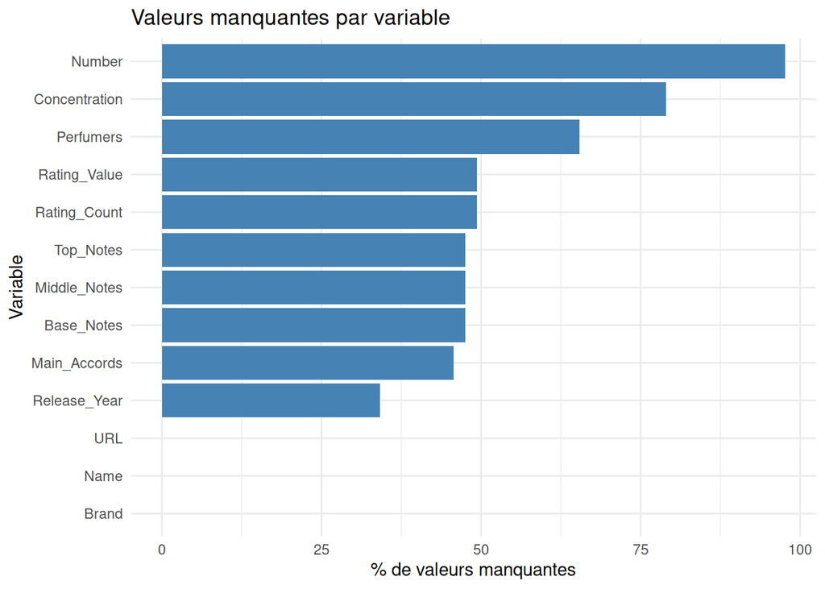

Figure 1: Pourcentage de valeurs manquantes par variable

```r
ggplot(na_df, aes(x = reorder(Variable, Pourcentage), y = Pourcentage)) +
  geom_bar(stat = "identity", fill = "steelblue") +
  coord_flip() +
  labs(x = "Variable", y = "% de valeurs manquantes",
       title = "Valeurs manquantes par variable") +
  theme_minimal()
```

Comme le montre la Figure 1, certaines variables présentent un taux élevé de valeurs manquantes.

## Création de la variable cible : Satisfaction

Nous conservons uniquement les parfums ayant une note (`Rating_Value` non manquante) et créons la variable binaire **Satisfaction** :

- **Oui** : `Rating_Value` >= médiane
- **Non** : `Rating_Value` < médiane

```r
data_rated <- data_raw %>%
  filter(!is.na(Rating_Value))

cat("Parfums avec une note :", nrow(data_rated), "\n")
```

```
Parfums avec une note : 30046
```

```r
mediane_rating <- median(data_rated$Rating_Value, na.rm = TRUE)
cat("Médiane de Rating_Value :", mediane_rating, "\n")
```

```
Médiane de Rating_Value : 7.4
```

```r
data_rated <- data_rated %>%
  mutate(Satisfaction = factor(ifelse(Rating_Value >= mediane_rating, "Oui", "Non"),
                               levels = c("Non", "Oui")))

table(data_rated$Satisfaction)
```

```
  Non   Oui
13716 16330
```

```r
prop.table(table(data_rated$Satisfaction))
```

```
   Non    Oui
0.4565 0.5435
```

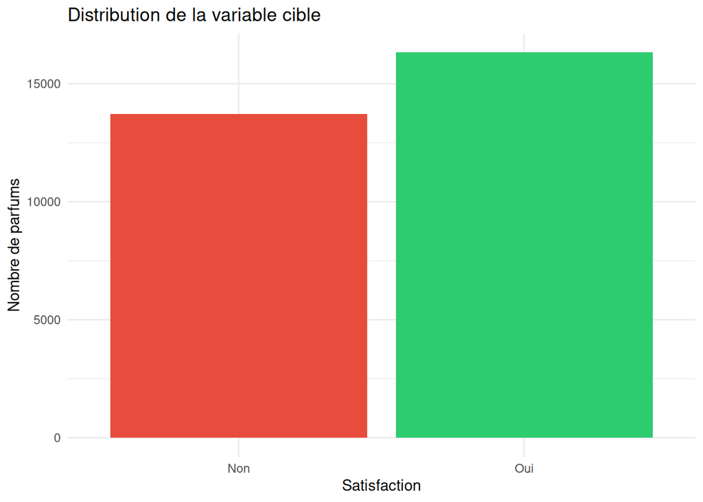

Figure 2: Distribution de la variable Satisfaction

```r
ggplot(data_rated, aes(x = Satisfaction, fill = Satisfaction)) +
  geom_bar() +
  scale_fill_manual(values = c("Non" = "#E74C3C", "Oui" = "#2ECC71")) +
  labs(x = "Satisfaction", y = "Nombre de parfums",
       title = "Distribution de la variable cible") +
  theme_minimal() +
  theme(legend.position = "none")
```

**NoteObservation**

La variable cible est relativement équilibrée grâce à l’utilisation de la médiane comme seuil de binarisation.

## Analyse univariée

### Rating_Value (avant binarisation)

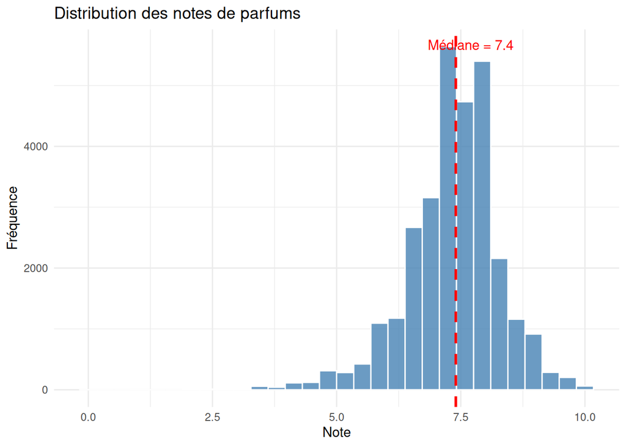

Figure 3: Distribution de Rating_Value

```r
ggplot(data_rated, aes(x = Rating_Value)) +
  geom_histogram(bins = 30, fill = "steelblue", color = "white", alpha = 0.8) +
  geom_vline(xintercept = mediane_rating, color = "red", linetype = "dashed", linewidth = 1) +
  annotate("text", x = mediane_rating + 0.3, y = Inf, vjust = 2,
           label = paste("Médiane =", mediane_rating), color = "red") +
  labs(x = "Note", y = "Fréquence",
       title = "Distribution des notes de parfums") +
  theme_minimal()
```

### Release_Year

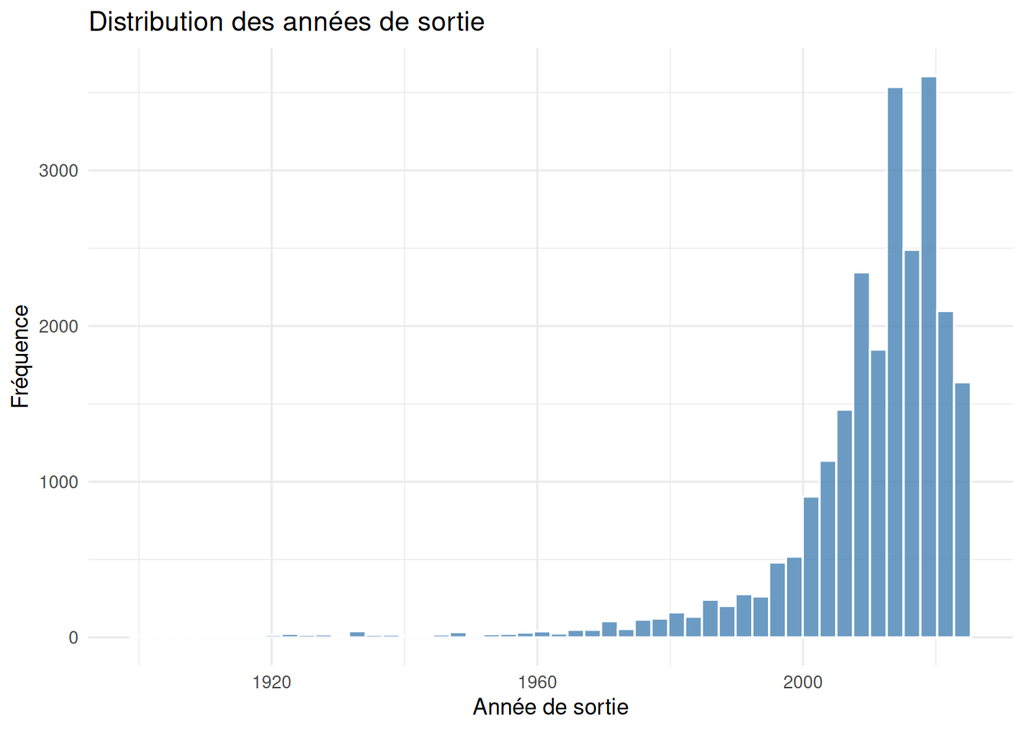

Figure 4: Distribution de Release_Year

```r
data_rated %>%
  filter(!is.na(Release_Year), Release_Year >= 1900) %>%
  ggplot(aes(x = Release_Year)) +
  geom_histogram(bins = 50, fill = "steelblue", color = "white", alpha = 0.8) +
  labs(x = "Année de sortie", y = "Fréquence",
       title = "Distribution des années de sortie") +
  theme_minimal()
```

### Rating_Count

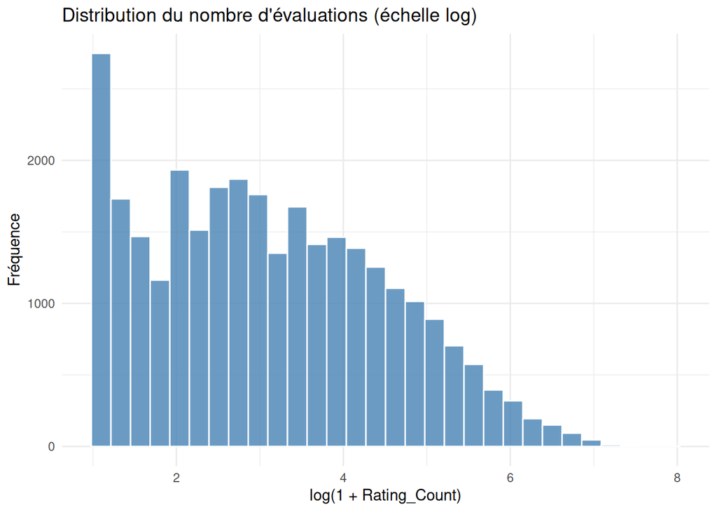

Figure 5: Distribution de Rating_Count (échelle log)

```r
data_rated %>%
  filter(!is.na(Rating_Count), Rating_Count > 0) %>%
  ggplot(aes(x = log1p(Rating_Count))) +
  geom_histogram(bins = 30, fill = "steelblue", color = "white", alpha = 0.8) +
  labs(x = "log(1 + Rating_Count)", y = "Fréquence",
       title = "Distribution du nombre d'évaluations (échelle log)") +
  theme_minimal()
```

### Concentration

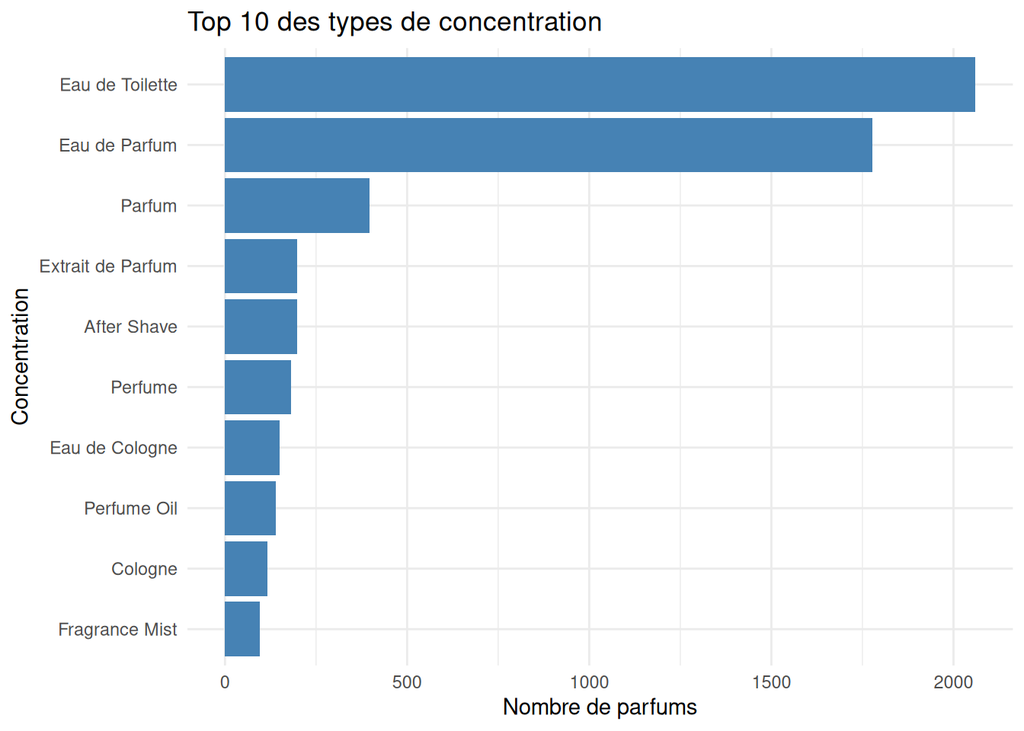

Figure 6: Distribution des types de concentration

```r
data_rated %>%
  filter(!is.na(Concentration)) %>%
  count(Concentration, sort = TRUE) %>%
  head(10) %>%
  ggplot(aes(x = reorder(Concentration, n), y = n)) +
  geom_bar(stat = "identity", fill = "steelblue") +
  coord_flip() +
  labs(x = "Concentration", y = "Nombre de parfums",
       title = "Top 10 des types de concentration") +
  theme_minimal()
```

### Main_Accords (accords les plus fréquents)

```r
n_parfums <- sum(!is.na(data_rated$Main_Accords))

accords_all <- data_rated %>%
  filter(!is.na(Main_Accords)) %>%
  pull(Main_Accords) %>%
  str_split(",\\s*") %>%
  unlist() %>%
  str_trim()

accords_freq <- as.data.frame(table(accords_all), stringsAsFactors = FALSE)
colnames(accords_freq) <- c("Accord", "Freq")
accords_freq <- accords_freq %>%
  mutate(Pct = Freq / n_parfums * 100) %>%
  arrange(desc(Freq))

n_total_accords <- nrow(accords_freq)
cat("Nombre total d'accords distincts :", n_total_accords, "\n")
```

```
Nombre total d'accords distincts : 21
```

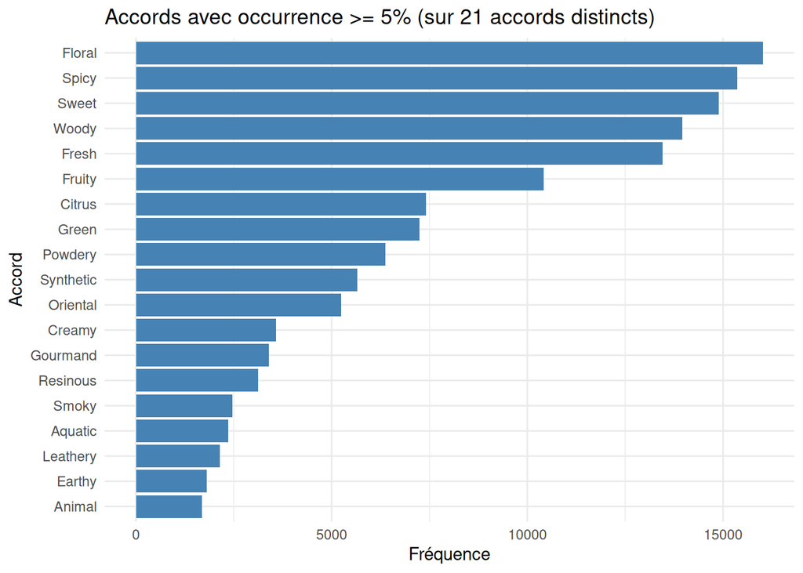

Figure 7: Accords olfactifs avec une occurrence d’au moins 5%

```r
accords_freq %>%
  filter(Pct >= 5) %>%
  ggplot(aes(x = reorder(Accord, Freq), y = Freq)) +
  geom_bar(stat = "identity", fill = "steelblue") +
  coord_flip() +
  labs(x = "Accord", y = "Fréquence",
       title = paste0("Accords avec occurrence >= 5% (sur ", n_total_accords, " accords distincts)")) +
  theme_minimal()
```

## Analyse multivariée

### Satisfaction vs. Rating_Count

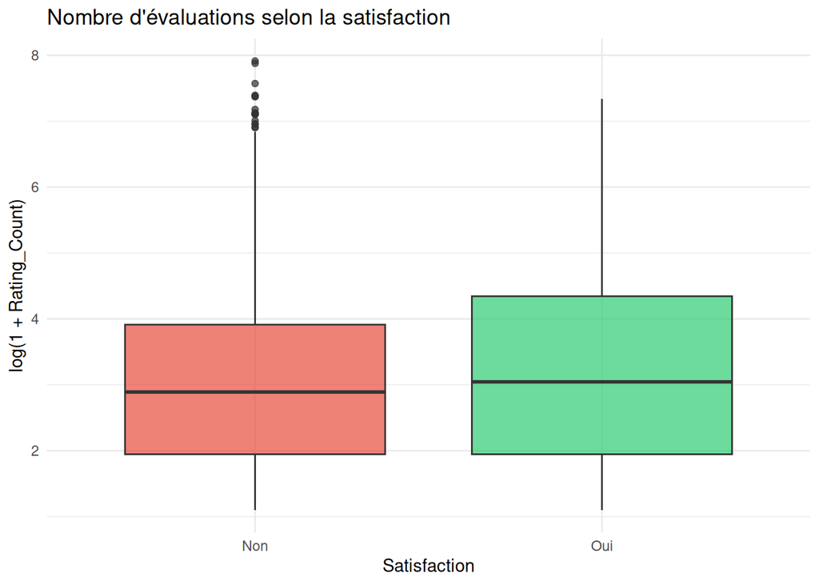

Figure 8: Rating_Count selon la Satisfaction

```r
data_rated %>%
  filter(!is.na(Rating_Count)) %>%
  ggplot(aes(x = Satisfaction, y = log1p(Rating_Count), fill = Satisfaction)) +
  geom_boxplot(alpha = 0.7) +
  scale_fill_manual(values = c("Non" = "#E74C3C", "Oui" = "#2ECC71")) +
  labs(x = "Satisfaction", y = "log(1 + Rating_Count)",
       title = "Nombre d'évaluations selon la satisfaction") +
  theme_minimal() +
  theme(legend.position = "none")
```

### Satisfaction vs. Release_Year

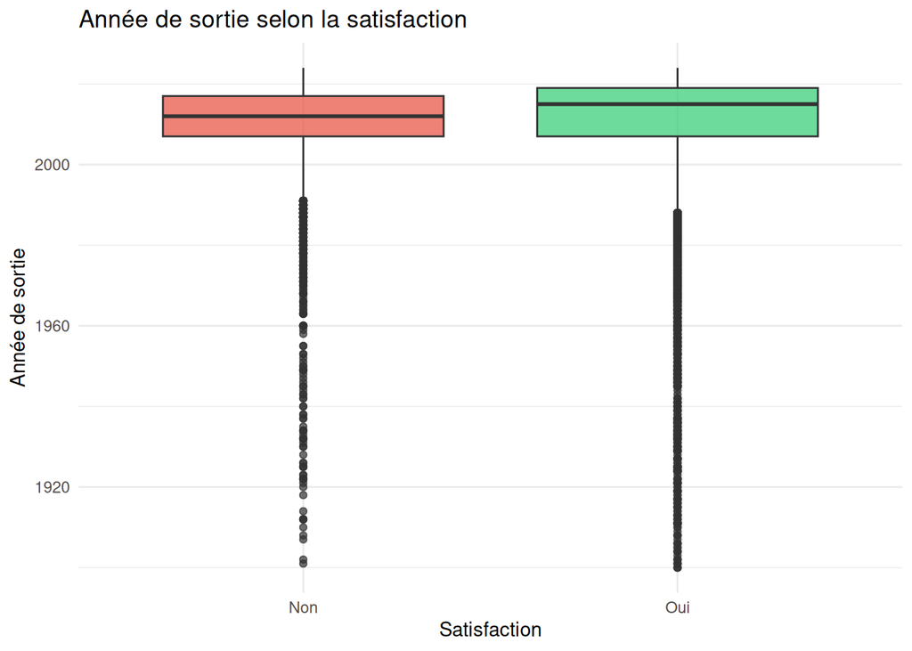

Figure 9: Année de sortie selon la Satisfaction

```r
data_rated %>%
  filter(!is.na(Release_Year), Release_Year >= 1900) %>%
  ggplot(aes(x = Satisfaction, y = Release_Year, fill = Satisfaction)) +
  geom_boxplot(alpha = 0.7) +
  scale_fill_manual(values = c("Non" = "#E74C3C", "Oui" = "#2ECC71")) +
  labs(x = "Satisfaction", y = "Année de sortie",
       title = "Année de sortie selon la satisfaction") +
  theme_minimal() +
  theme(legend.position = "none")
```

### Satisfaction vs. Concentration

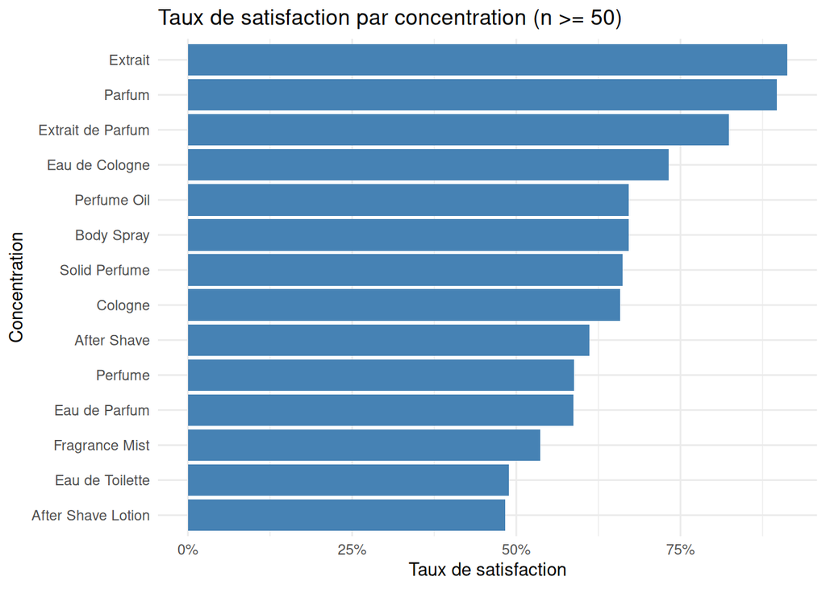

Figure 10: Taux de satisfaction par type de concentration

```r
data_rated %>%
  filter(!is.na(Concentration)) %>%
  group_by(Concentration) %>%
  filter(n() >= 50) %>%
  summarise(
    n = n(),
    taux_satisfaction = mean(Satisfaction == "Oui"),
    .groups = "drop"
  ) %>%
  ggplot(aes(x = reorder(Concentration, taux_satisfaction), y = taux_satisfaction)) +
  geom_bar(stat = "identity", fill = "steelblue") +
  coord_flip() +
  scale_y_continuous(labels = scales::percent) +
  labs(x = "Concentration", y = "Taux de satisfaction",
       title = "Taux de satisfaction par concentration (n >= 50)") +
  theme_minimal()
```

### Corrélation entre variables numériques

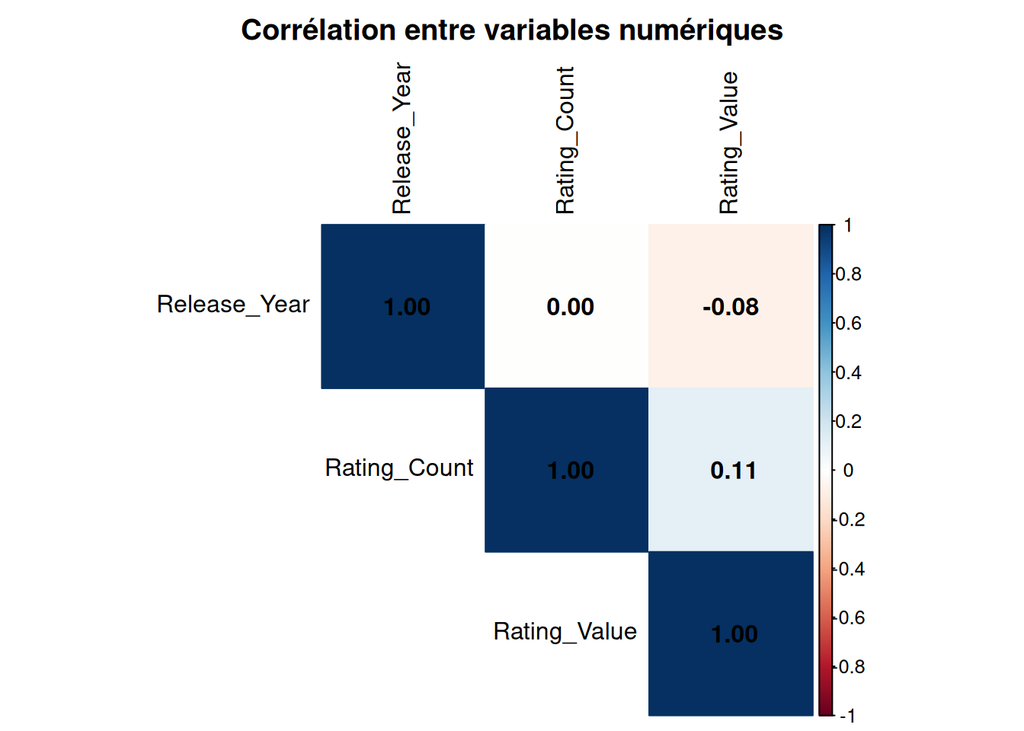

Figure 11: Matrice de corrélation

```r
num_vars <- data_rated %>%
  select(Release_Year, Rating_Count, Rating_Value) %>%
  filter(complete.cases(.))

cor_matrix <- cor(num_vars)
corrplot(cor_matrix, method = "color", type = "upper",
         addCoef.col = "black", tl.col = "black",
         title = "Corrélation entre variables numériques",
         mar = c(0, 0, 2, 0))
```

# Sauvegarde des données

```r
saveRDS(data_rated, here::here("output", "data_rated.rds"))
cat("data_rated sauvegardé dans output/data_rated.rds\n")
```

```
data_rated sauvegardé dans output/data_rated.rds
```

```r
cat("Dimensions :", nrow(data_rated), "x", ncol(data_rated), "\n")
```

```
Dimensions : 30046 x 14
```